# Practice 5

Guglielmo Bonifazi, Emanuele Sorgente

01/11/2021

```r
library(Epi)
library(readr)
library(glmnet)
```

```r
library(MASS)
library(corrplot)
library(car)
```

Excercise 1

```r
challenger = read_csv("C:/Users/Emanuele/OneDrive/Desktop/3° Anno Uni/Statistical Learning/practice5/challenger.csv")
model= glm(fail.field ~ temp, family = "binomial", data = challenger)
```

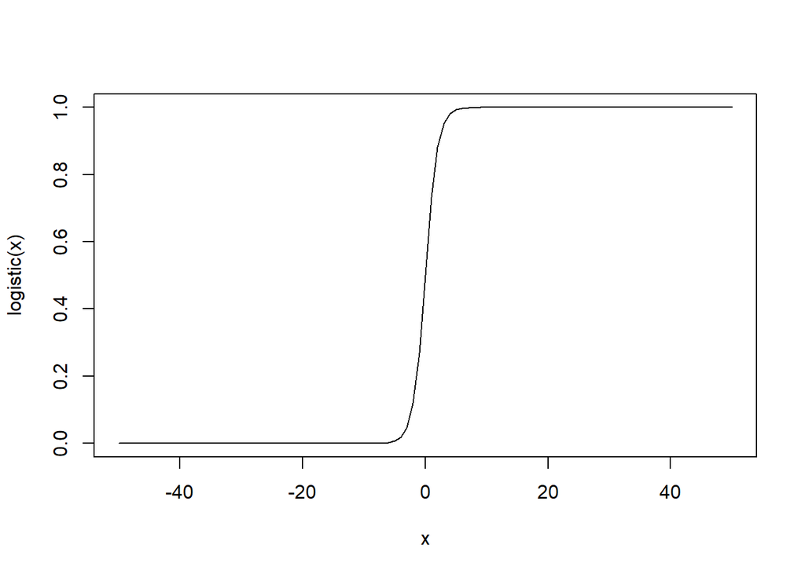

```r
logistic=function(eta){
  k=exp(-eta)
  l=1/(1+k)
  return(l)
}

logit=function(p){
  k=p/(1-p)
  return (log(k))
}

curve(logistic(x),from=-50,to=50)
```

The logistic function image is (0,1), it is supported by the theory, indeed it is chosen to represent the probability of having a success given an X which produces that eta. Even from the graphic it is evident

As a consequence its inverse will have like domain (0,1)

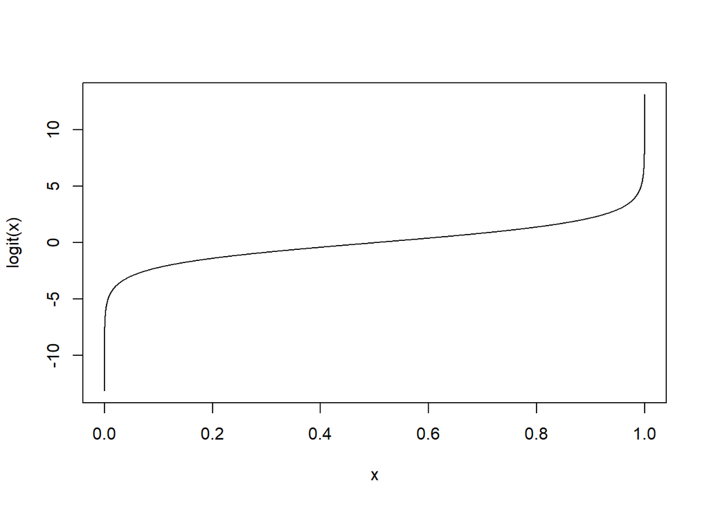

```r
curve(logit(x),from=0,to=1,n=500000)
```

Its image is (-Inf,Inf), obviously like the Domain of the logistic function.

2. The function which describes the odds is the following:

Note that with n we are encoding beta0+beta1* x1+…+betap*xp

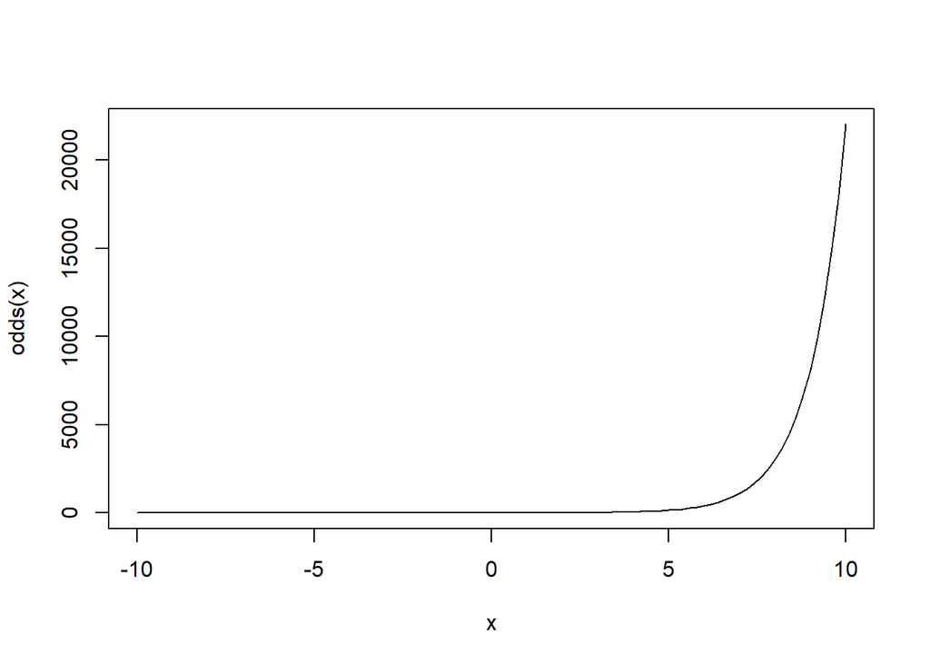

```r
odds=function(n){
  return (exp(n))
}
curve(odds(x),from=-10,to=10)
```

We can observe as the odds, being a ratio between probabilities, have always a positive value. As they approach zero the denominator and so the probability of having a failure, will be higher than the probability of observing a success. On the contrary, as the odds tends to infinity, the probability of failure will be insignificant, with regard to the one of success.

If the probability of observing a failure and not observing it are equal, then the odds will be equal to one. As a consequence, the answer to the question is the value of y_hat that will make the odds equal to one, which is 0. Indeed the odds are simply the number of nepero powered to the linear prediction.

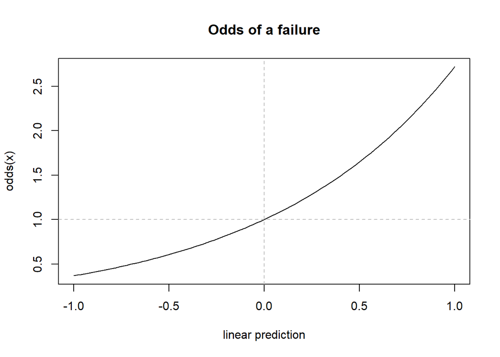

```r
curve(odds(x),from=-1,to=1,xlab='linear prediction')
title(main='Odds of a failure')
abline(h=1,lty=2,col='grey')
abline(v=0,lty=2,col='grey')
```

```r
odds(0)
```

```
## [1] 1
```

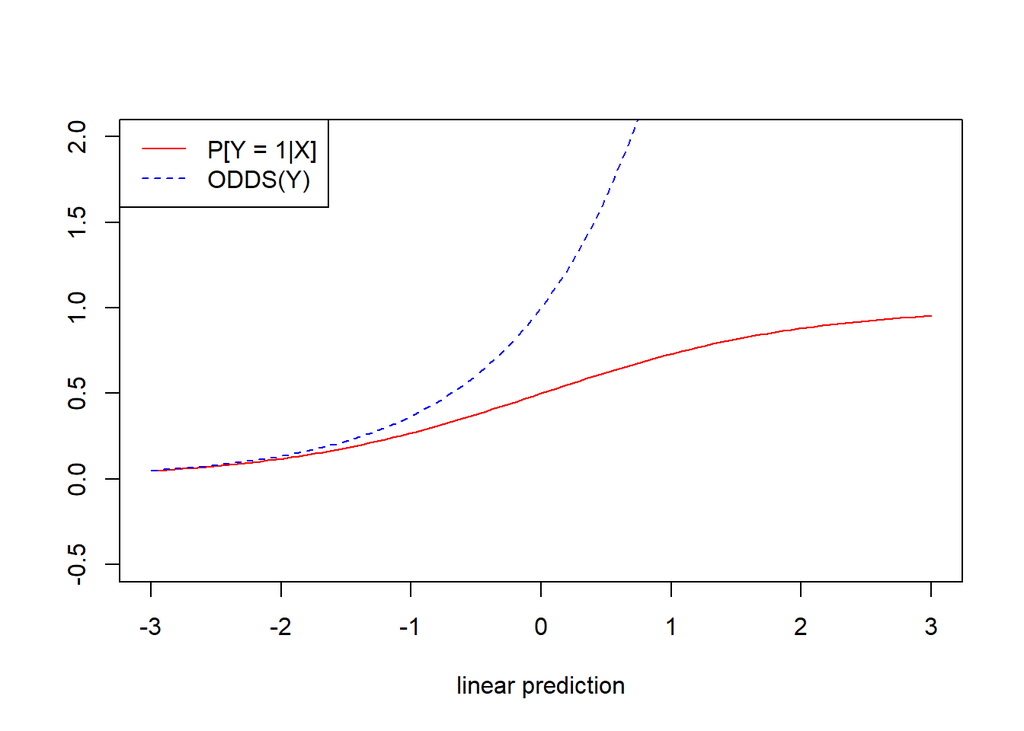

```r
curve(logistic(x),from=-3,to=3,col='red',xlab='linear prediction',ylab='',ylim=c(-0.5,2))
curve(odds(x),add=T,col='blue',lty=2)
legend('topleft',legend=c('P[Y = 1|X]','ODDS(Y)'),col=c('red','blue'),lty=c(1,2))
```

4. Odds(Y|X1=x1)/Odds(Y|X1=x1+1)= 1/exp{Beta1}=exp{-Beta1} Actually the function depends only on Beta1. Indeed, exp{-Beta1} is the factor by which the odds of observing a Failure are multiplied in case of recording a unitary decrease of temperature. Being Beta1 negative, this will result in an increase in the odds of having a success, which in this case is equal to:

```r
exp(0.4166)
```

```
## [1] 1.516796
```

So observing 1 degree less in the temperature will make the Odds of observing a success 50% greater. exp{Beta0} is instead representing ODDS[Y = 1|X=0]. So the the odds of observing a success given that the temperature is equal to 0. In this case:

```r
exp(7.5837)
```

```
## [1] 1965.889
```

The model suggests that observing a success with 0 degrees would be almost 2 thousands time more likely to observing a failure

Log Likelihood function

```r
y=challenger$fail.field
x=challenger$temp
log_lik=function(Beta0,Beta1){
  n=Beta0+Beta1*x
  p=logistic(n)
  ret=sum(log(p^y*(1-p)^(1-y)))
  return(ret)
}
model$coefficients
```

```
## (Intercept)        temp
##   7.5837433  -0.4166465
```

```r
log_lik(model$coefficients[1],model$coefficients[2])
```

```
## [1] -10.16743
```

```r
log_lik(0,-3)
```

```
## [1] -369.9
```

As we expect the coefficients of the logistic model produce an higher likelihood, indeed they are obtained with the Maximum Likelihood approach

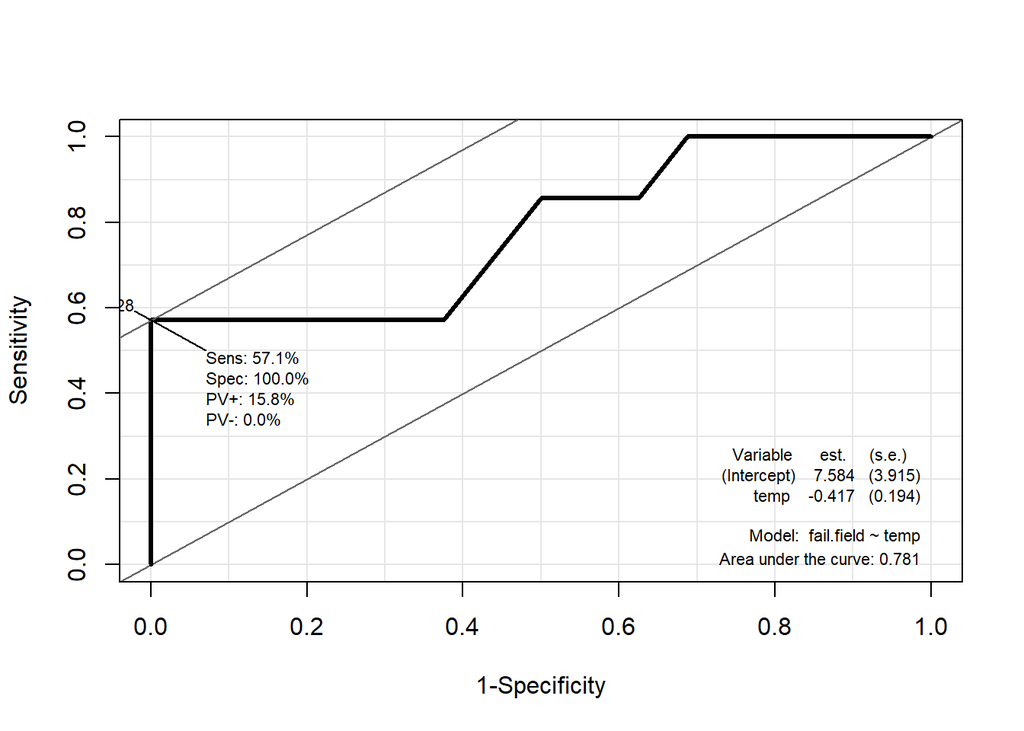

```r
roc=ROC(form=fail.field~temp, data=challenger, plot="ROC",lwd=3,cex=1.5)
```

```r
roc$AUC
```

```
## [1] 0.78125
```

Our classifier is quite good basing on the Area under Curve.

```r
R_squared=1-(model$deviance/model$null.deviance)
R_squared
```

```
## [1] 0.280619
```

But it fits poorly the data based on the R_squared.

Excercise 2

```r
health=read.table(file.choose(),header=TRUE)
str(health)
```

```
## 'data.frame':    7357 obs. of  11 variables:
##  $ sex    : int  1 1 1 1 1 1 1 1 1 1 ...
##  $ g01    : int  2 2 2 2 1 2 1 1 1 1 ...
##  $ g02    : int  1 1 1 1 1 1 1 1 1 1 ...
##  $ weight : int  67 76 77 75 76 84 94 78 65 75 ...
##  $ height : int  165 166 178 175 177 174 197 178 162 172 ...
##  $ con_tab: int  1 2 2 1 2 1 1 1 1 1 ...
##  $ year   : int  2002 2004 2002 2002 2003 2003 2002 2003 2001 2003 ...
##  $ educa  : int  4 2 4 3 4 4 3 3 4 3 ...
##  $ imc    : num  24.6 27.6 24.3 24.5 24.3 ...
##  $ drink  : int  1 1 1 1 1 1 1 1 1 0 ...
##  $ age    : int  25 43 29 35 38 50 26 29 28 22 ...
```

```r
names(health)
```

```
##  [1] "sex"     "g01"     "g02"     "weight"  "height"  "con_tab" "year"
##  [8] "educa"   "imc"     "drink"   "age"
```

```r
health=health[,-2]
```

dropping down g01

```r
indexes_cat=c(1,2,5,7,9)
```

Factorizing categorical variables

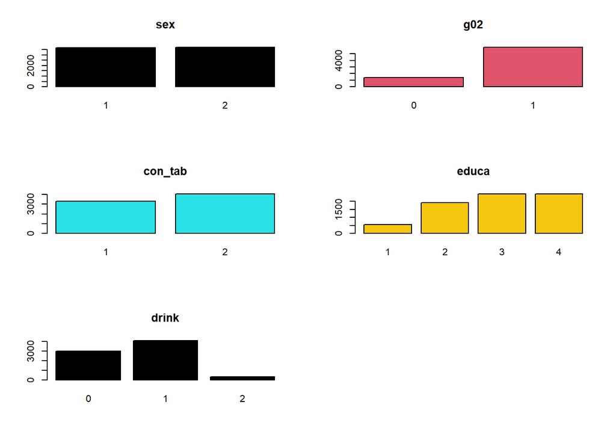

```r
for (i in indexes_cat){
  health[,i]=as.factor(health[,i])
}

x11()
par(mfrow=c(3,2))
for (i in indexes_cat){
  barplot(table(health[,i]),main=colnames(health)[i],col=i)
}
```

We can observe as the population is almost perfectly balanced with regard to gender and tobacco consumption. Only a small percentage of the patients has a ow level of education and the other part is spread between the other levels with a majority in high and median-high levels. The ratio between people in good health to people in bad health is almost four. Finally, frequent alcohol consumer are almost not present in the population.

[figure not shown]

```r
par(mfrow=c(4,2))
l=c(3,4,8,10)
for (i in l){
  hist(health[,i],col=i,main=names(health)[i],xlab='')
  boxplot(health[,i],col=i,main=names(health)[i],xlab='')
  }
```

```r
summary(health[,l])
```

```
##      weight           height           imc             age
##  Min.   : 34.00   Min.   :120.0   Min.   :14.69   Min.   :18.00
##  1st Qu.: 59.00   1st Qu.:161.0   1st Qu.:21.72   1st Qu.:28.00
##  Median : 69.00   Median :168.0   Median :24.06   Median :39.00
##  Mean   : 69.51   Mean   :168.5   Mean   :24.39   Mean   :39.24
##  3rd Qu.: 79.00   3rd Qu.:175.0   3rd Qu.:26.53   3rd Qu.:49.00
##  Max.   :175.00   Max.   :200.0   Max.   :62.87   Max.   :64.00
```

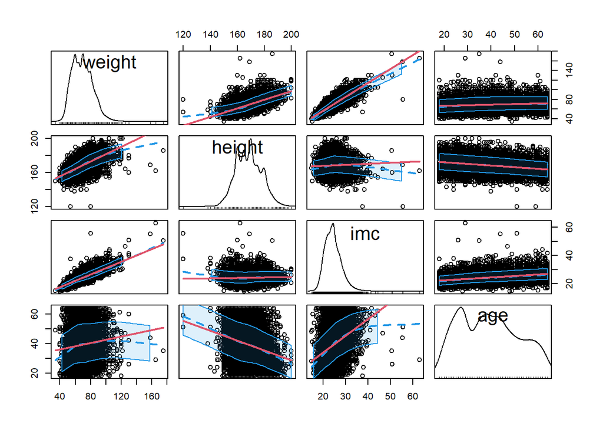

```r
par(mfrow=c(1,2))
scatterplotMatrix(health[,l], col = 1, regLine = list(col = 2),
                  smooth = list(col.smooth = 4, col.spread = 4))
```

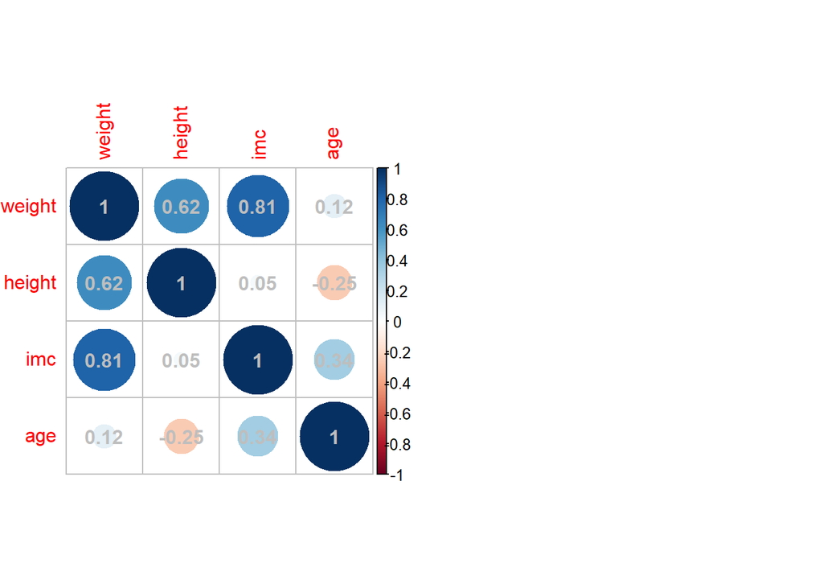

```r
corrplot(cor(health[,l]), addCoef.col = "grey")
```

From this graphical and numerical synthesis, the most important aspects are: The range of age take into account is between 18 and 64 years, and the IQR is between 28 and 49. so that there are not extremely young or old people. The weight distribution is characterized by some heavy outliers in the positive direction. There is a very strong linear relationship between weight and imc, indeed the latter as well presents outliers

2. From the experience learned in the previous practice we will use the following approach:

fitting a lasso regression to the logistic model in order to select a good starting model, which has been prived by insignificant variables.

The lasso will be used as initial model for the stepwise algorithm. This will have as scope a more saturated model, which will include as well some interactions, based on intuition. Doubtless we could as well include all the interactions, but being the stepwise selection a greedy alghoritm, enlarging so much the space of possible solutions would probably result in poorer performances. Besides the cost of the computation would be extremely high.

Lasso logistic Regression

```r
x = model.matrix(g02~., health)[,-1]
```

For categorical variable the encoding is the following: namevark takes 1 if the original var=k, 0 otherwise. So for example sex2 takes 1 if the sex is female, as in the previous encoding female=2

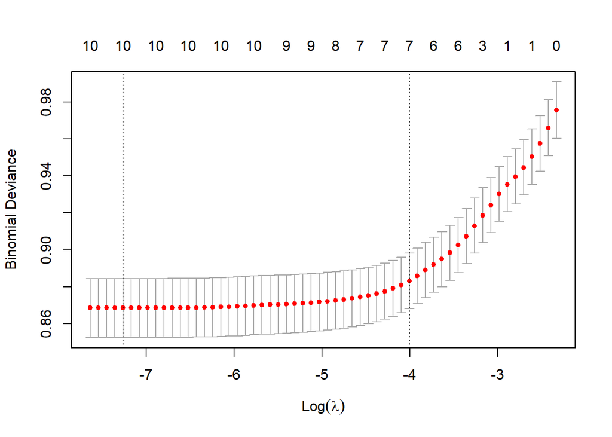

```r
y = as.integer(health$g02==1)

set.seed(7)
cv.lasso=cv.glmnet(x = x, y = y,family='binomial', alpha = 1, nfolds = 20)
par(mfrow=c(1,1))
plot(cv.lasso)
```

We can notice that even if the lambda is reached near the edge of the grid used by default, its value is extremely low and produce the shrink of only two variables so that it would be useless to look for a lower lambda.

```r
lasso.model_min= glmnet(x, y, alpha = 1, family = "binomial",
                        lambda = cv.lasso$lambda.min)
coef(lasso.model_min)
```

```
## 13 x 1 sparse Matrix of class "dgCMatrix"
##                       s0
## (Intercept)  3.001618667
## sex2        -0.298431652
## weight       .
## height       0.005107714
## con_tab2    -0.129066419
## year         .
## educa2       0.275898490
## educa3       0.758798146
## educa4       1.117044554
## imc         -0.064320055
## drink1       0.428910652
## drink2       0.370675521
## age         -0.034963877
```

Tear and weight are the only variables shrink to zero using the optimal minimum value as penalty parameter. It is not surprising that the year in which the observation was recorded is not significant to the health state of the subject. Besides,the information we can extract from the weight is valid only if it is related to the height of the patient, and this role is already played by imc, so that it is not surprising its absence. We must remember, besides, that imc and weight have high correlation, as a consequence it is dropping down one of them is essential.

```r
lasso.model_1se= glmnet(x, y, alpha = 1, family = "binomial",
                        lambda = cv.lasso$lambda.1se)
coef(lasso.model_1se)
```

```
## 13 x 1 sparse Matrix of class "dgCMatrix"
##                       s0
## (Intercept)  1.969792002
## sex2        -0.026492324
## weight       .
## height       0.008673388
## con_tab2     .
## year         .
## educa2       .
## educa3       0.166748402
## educa4       0.505326687
## imc         -0.038869550
## drink1       0.232859423
## drink2       .
## age         -0.032369637
```

The additional variables dropped to 0 by the more heavier penalization parameter lambda 1se are: being a smoker, being a frequent drinker and being low-median educated. Nonetheless the first two variables are extremely counter-intuitive as being a smoker or a frequent drinker are known to be important feature in determining the health status. Regarding being a frequent alchol consumer, it is known from the descriptive analysis which there are very few cases in the dataset, so that the variable presents poor variability and so it is not very informative.

As our objective is to have an initial model which lacks insignificant variables we will use the 1se lambda.

SETTING THE FULL MODEL: We include in the matrix as well the interactions between age and alcohol or tobacco consume, as their effects are powered if the body of the subject is older. Besides, as we previously stated, from a medical point of view it is extremely strange that have been dropped down by the lasso (even though we had found a reason for the drink variable), as a consequence,it could be a good approach to test their significance in affecting other variables contributes,such age.

```r
x = model.matrix(g02 ~ sex + weight + height + con_tab + year + educa +
                   imc + drink + age +(age+drink)^2+(age+con_tab)^2, health)[,-1]
g02=y
health_new=cbind(data.frame(x),g02)

full = glm(g02 ~ sex2 + weight + height + con_tab2 + year + educa2 + educa3 +
                          educa4 + imc + drink1 + drink2 + age + drink1:age + drink2:age +
                          con_tab2:age,family='binomial', data = health_new)
full
```

```
##
## Call:  glm(formula = g02 ~ sex2 + weight + height + con_tab2 + year +
##     educa2 + educa3 + educa4 + imc + drink1 + drink2 + age +
##     drink1:age + drink2:age + con_tab2:age, family = "binomial",
##     data = health_new)
##
## Coefficients:
##  (Intercept)          sex2        weight        height      con_tab2
##    5.8945635    -0.2844986     0.0056356     0.0007194    -0.4368733
##         year        educa2        educa3        educa4           imc
##   -0.0009182     0.3244776     0.7979636     1.1546033    -0.0801567
##       drink1        drink2           age    drink1:age    drink2:age
##    0.0922970    -0.6179516    -0.0431616     0.0080204     0.0241782
## con_tab2:age
##    0.0065684
##
## Degrees of Freedom: 7356 Total (i.e. Null);  7341 Residual
## Null Deviance:       7178
## Residual Deviance: 6358  AIC: 6390
```

```r
null=glm(g02~1,data=health,family = 'binomial')
null
```

```
##
## Call:  glm(formula = g02 ~ 1, family = "binomial", data = health)
##
## Coefficients:
## (Intercept)
##       1.443
##
## Degrees of Freedom: 7356 Total (i.e. Null);  7356 Residual
## Null Deviance:       7178
## Residual Deviance: 7178  AIC: 7180
```

Setting the lasso based on the new matrix

```r
mod.lasso.CV=cv.lasso$glmnet.fit
predictors.lasso =predict(mod.lasso.CV, type = "coefficients", s =  cv.lasso$lambda.1se)
sel.preds=predictors.lasso[-1, ] != 0
f_lasso_1se=formula(paste("g02 ~", paste(names(which(sel.preds)), collapse = " + ")))
mod_lasso_1se=glm(f_lasso_1se,family='binomial',data=health_new)
mod_lasso_1se
```

```
##
## Call:  glm(formula = f_lasso_1se, family = "binomial", data = health_new)
##
## Coefficients:
## (Intercept)         sex2       height       educa3       educa4          imc
##    3.301869    -0.317805     0.004947     0.553357     0.931604    -0.065607
##      drink1          age
##    0.398710    -0.036605
##
## Degrees of Freedom: 7356 Total (i.e. Null);  7349 Residual
## Null Deviance:       7178
## Residual Deviance: 6385  AIC: 6401
```

STEWISE ALGHORITM

```r
final_mod=stepAIC(mod_lasso_1se, direction = "forward",
        scope = list(lower = null, upper = full), k = log(nrow(health_new)),trace=0)
```

Starting from some model // If noise variables are included in initial model, they are never dropped.

```r
final_mod
```

```
##
## Call:  glm(formula = g02 ~ sex2 + height + educa3 + educa4 + imc + drink1 +
##     age + educa2, family = "binomial", data = health_new)
##
## Coefficients:
## (Intercept)         sex2       height       educa3       educa4          imc
##    3.025716    -0.318786     0.004491     0.815563     1.189042    -0.064599
##      drink1          age       educa2
##    0.391598    -0.034818     0.328505
##
## Degrees of Freedom: 7356 Total (i.e. Null);  7348 Residual
## Null Deviance:       7178
## Residual Deviance: 6376  AIC: 6394
```

As we can observe the only variables which has been added is the categorical corresponding to being low-median educated. So we have had a further confirm of the fact that alcohol and cigarette frequent consumption are not relevant for determining the health.

Checking the significance and the interpretation of the coefficients

```r
summary(final_mod)
```

```
##
## Call:
## glm(formula = g02 ~ sex2 + height + educa3 + educa4 + imc + drink1 +
##     age + educa2, family = "binomial", data = health_new)
##
## Deviance Residuals:
##     Min       1Q   Median       3Q      Max
## -2.5724   0.3445   0.4771   0.6415   1.7534
##
## Coefficients:
##              Estimate Std. Error z value Pr(>|z|)
## (Intercept)  3.025716   0.935197   3.235 0.001215 **
## sex2        -0.318786   0.091370  -3.489 0.000485 ***
## height       0.004491   0.004933   0.910 0.362578
## educa3       0.815563   0.115276   7.075 1.50e-12 ***
## educa4       1.189042   0.117374  10.130  < 2e-16 ***
## imc         -0.064599   0.008584  -7.526 5.25e-14 ***
## drink1       0.391598   0.065233   6.003 1.94e-09 ***
## age         -0.034818   0.002902 -11.998  < 2e-16 ***
## educa2       0.328505   0.106851   3.074 0.002109 **
## ---
## Signif. codes:  0 '***' 0.001 '**' 0.01 '*' 0.05 '.' 0.1 ' ' 1
##
## (Dispersion parameter for binomial family taken to be 1)
##
##     Null deviance: 7177.9  on 7356  degrees of freedom
## Residual deviance: 6376.1  on 7348  degrees of freedom
## AIC: 6394.1
##
## Number of Fisher Scoring iterations: 5
```

```r
m=glm(formula = g02 ~ sex2  + educa3 + educa4 + imc + drink1 +
        age + educa2, family = "binomial", data = health_new)

BIC(final_mod,m)
```

```
##           df      BIC
## final_mod  9 6456.202
## m          8 6448.128
```

The interpretations are the following:

```r
exp(final_mod$coefficients)
```

```
## (Intercept)        sex2      height      educa3      educa4         imc
##  20.6087463   0.7270312   1.0045013   2.2604487   3.2839325   0.9374428
##      drink1         age      educa2
##   1.4793423   0.9657815   1.3888903
```

Being a female decreases the odds of being in good health of 28% regarding education the odds are all increased by having a median-low,median-high or high educational level of 38%,126%,228%. We can observe that as the level of education increases, the probability of being in a good shape will as well rise. Having a imc greater of 1 unit will instead reduce the odds of about 6% being an occasional drinker will increase it of almost 50%, which is a very confusing result. For each additional centimeter of height the odds will increase of 0,4%, this is a very low value and indeed the coefficient is not reported as significant neither at a 10% level. At the end it is shown that for each additional age the odds decreases of 3,5%

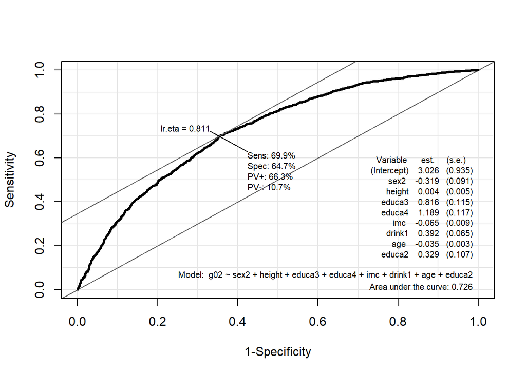

```r
roc=ROC(form=g02 ~ sex2 + height + educa3 + educa4 + imc + drink1 +
      age + educa2, data=health_new, plot="ROC",lwd=3,cex=1.5)
```

```r
p=predict(final_mod,health_new,type='response')
cutoffs=seq(0.15,0.96,length.out=100)
n=length(y)
metric=c()

for(cutoff in cutoffs){
  r=c()
  for (i in 1:n){
    if(p[i]>cutoff){r=c(r,1)}
    else{r=c(r,0)}
  }
  t=table(y,r)
  specificity=t[1,1]/sum(t[1,])
  sensitivity=t[2,2]/sum(t[2,])
  metric=c(metric,specificity+sensitivity)}

optimal_treshold=cutoffs[which.max(metric)]
max(metric)
```

```
## [1] 1.343322
```

```r
r=c()
for (i in 1:n){
  if(p[i]>optimal_treshold){r=c(r,1)}
  else{r=c(r,0)}
}
confusion_matrix=table(y,r)
confusion_matrix
```

```
##    r
## y      0    1
##   0  912  494
##   1 1817 4134
```

```r
opt_specificity=confusion_matrix[1,1]/sum(confusion_matrix[1,])
opt_sensitivity=confusion_matrix[2,2]/sum(confusion_matrix[2,])
c(opt_sensitivity,opt_specificity)
```

```
## [1] 0.6946732 0.6486486
```

The model is almost perfectly balanced but it has a slighty higher sensitivity, so people in good health are better recognized than people in a poor state.

4. If none of the predictors is significant, then the difference between D0 and D is asymptotically distributed as a Chi squared with p degrees of freedom. As a consequence we can formulate a test to verify that hypotheis.

```r
summary_final=summary(final_mod)
stat=summary_final$null.deviance-summary_final$deviance
treshold=qchisq(p=0.95,df=length(coef(final_mod)))
stat>treshold
```

```
## [1] TRUE
```

```r
p_value=1-pchisq(q=stat,df=length(coef(final_mod)))
p_value
```

```
## [1] 0
```

We strongly reject the null hypothesis and assume that at least one predictor is significant.

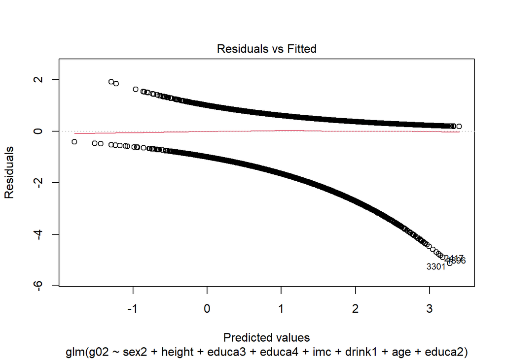

```r
plot(final_mod,1)
```

the linearity relationship between the predictors and the response is completely respected.

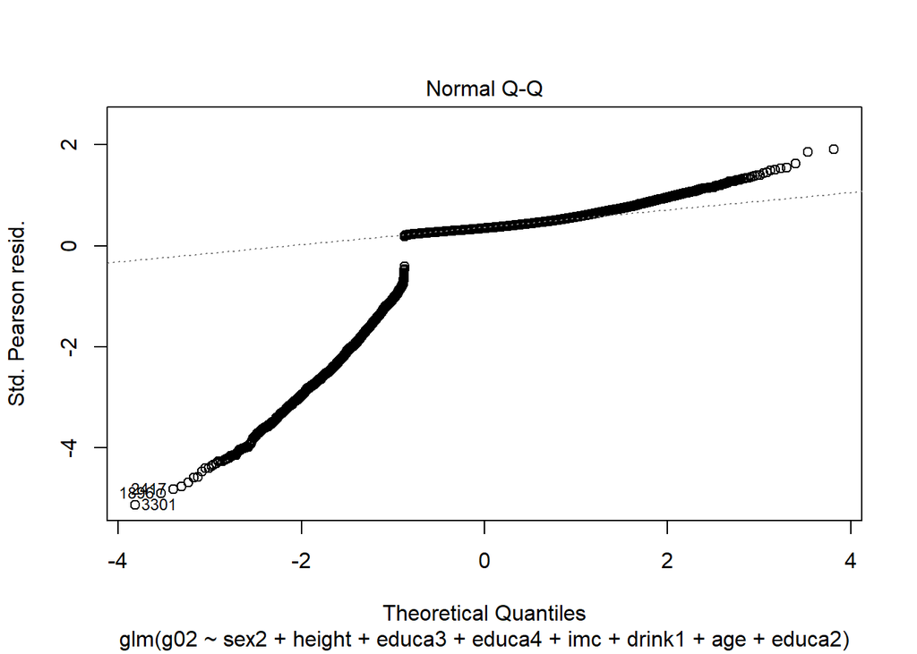

```r
plot(final_mod,2)
```

Normality is doubtless not respected but even a good logistic model could suffer from this condition, so that we cannot conclude nothing about its validity.

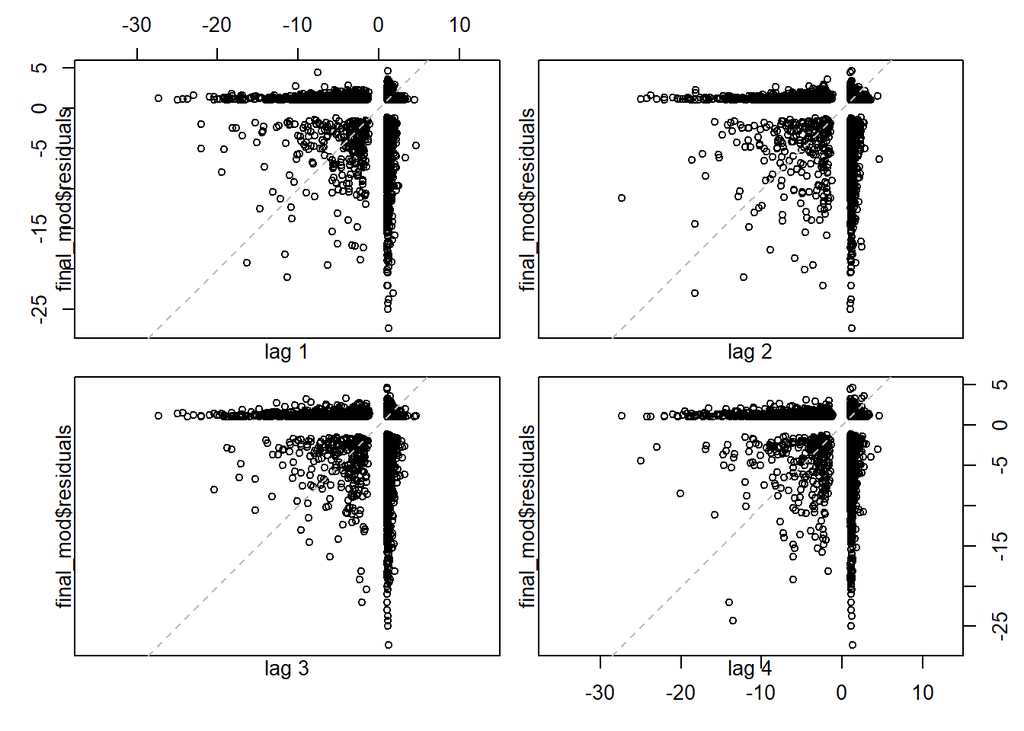

```r
lag.plot(final_mod$residuals, lags = 4, do.lines = FALSE)
```

```r
for (lag in seq(1,6,1)){
  print(paste0("Lag ", lag, ": ", cor(final_mod$residuals[-lag], final_mod$residuals[-length(final_mod$residuals)])))
}
```

```
## [1] "Lag 1: 0.00433112475418109"
## [1] "Lag 2: 0.00432748738466474"
## [1] "Lag 3: 0.00433188879194787"
## [1] "Lag 4: 0.00433113999377103"
## [1] "Lag 5: 0.00433157662910251"
## [1] "Lag 6: 0.00433041636469756"
```

```r
car::durbinWatsonTest(final_mod, max.lag = 4)
```

```
##  lag Autocorrelation D-W Statistic p-value
##    1      0.03472078      1.930434   0.004
##    2      0.02436876      1.950955   0.040
##    3      0.02552382      1.948595   0.030
##    4      0.03806634      1.923413   0.000
##  Alternative hypothesis: rho[lag] != 0
```

Even though from the visual inspection does not emerge a clear trend. The hypothesis of independence is rejected by the test.